# Análisis de redes

Autor

Diabb Zegpi

En este curso, realizaremos un análisis de redes aplicado a las [célebres Rimas](https://www.cjpb.org.uy/wp-content/uploads/repositorio/serviciosAlAfiliado/librosDigitales/Becquer-Rimas.pdf) de Gustavo Adolfo Bécquer. De acuerdo con el [glosario de visualización de datos de las bibliotecas Johns Hopkins](https://guides.library.jhu.edu/datavisualization/network), el análisis de redes “es una colección de técnicas para examinar las relaciones entre entidades, y representando la estructura de esas relaciones. El análisis de redes se extiende a un número de dominios, incluyendo redes sociales, bibliometría, epidemiología, bioinformática, sistemas complejos, y **análisis de texto**.”

Dividiremos el curso en la obtención de datos, limpieza de datos, tokenización, análisis exploratorio, procesamiento de texto y visualización de relaciones mediante redes.

### 1. Obtención de datos

Primero, obtendremos los datos del repositorio de libros digitales de la Caja de Jubilaciones y Pensiones Bancarias de Uruguay. De igual manera, encontrarán el libro de rimas en formato pdf en la unidad 2 de classroom. Para obtener los datos, utilizaremos el paquete `pdftools`, para trabajar con datos en pdf, y `tidyverse`, para manipulación, programación y visualización.

```r
library(tidyverse)
library(pdftools)

becquer_url <- 'Becquer-Rimas.pdf'
becquer <- pdf_text(becquer_url)
```

Observemos la estructura del objeto cargado en memoria.

```r
summary(becquer)
```

```
   Length     Class      Mode
       62 character character
```

Se trata de un vector de clase `character` (string), de largo 62, esto es, un elemento del vector para cada página en el pdf. ¿Cómo comienzan las páginas 1 y 15? Para ambas páginas, obtendremos un subconjunto de caracteres, desde el primero hasta el quingentésimo. Notemos que para haber 500 caracteres impresos, muchos de ellos deben ser espacios en blanco.

```r
# Página 1
becquer[1] |>
  str_sub(start = 1L, end = 500L) |>
  cat()
```

```
Rimas                                                 Gustavo Adolfo Becquer

                               Gustavo
                                Adolfo
                               Bécquer
                                  1836 – 1870


Prologo del autor


Por los tenebrosos rincones de mi cerebro acurrucados y desnudos
duermen los extravagantes hijos de mi fantasía esperando en silencio que el
Arte los vista de la palabra para poder presentarse decentes en la escena del
mundo.

Fecunda
```

```r
# Página 15
becquer[15] |>
  str_sub(start = 1L, end = 500L) |>
  cat()
```

```
Rimas                                   Gustavo Adolfo Becquer

              Es tu mejilla temprana
            rosa de escarcha cubierta
         en que el carmín de los pétalos
           se ve a través de las perlas

         Y, sin embargo, sé que te quejas,
        porque tus ojos crees que la afean:
                 pues no lo creas;
              que parecen tus pupilas,
           húmedas, verdes e inquietas,
          tempranas hojas de almendro,
           que al soplo del aire tiemb
```

### 2. Limpieza de datos

El objetivo de esta etapa es transformar el texto en bruto (pdf) en un dataframe, porque es la estructura de datos más fácil de manipular para hacer ciencia de datos.

Observemos (en el pdf) que las páginas 1 a 3 contienen el prólogo del autor, Gustavo Bécquer. En este caso de uso, nos concentraremos en el contenido de las rimas, por ende, debemos excluir el prólogo. Excluir las páginas 1 y 2 es sencillo.

```r
becquer <- becquer[-c(1, 2)]
```

Ahora, debemos separar el prólogo de las rimas en la página 1 (ex página 3). Para ello, aprovecharemos que la primera rima comienza con el título **RIMA I**. Para seleccionar el primer título y todo el texto que le prosigue, usaremos `str_match()` con la expresión regular `RIMA.+`, empleando el argumento `dotall = TRUE`. Esto último significa que el comodín de la expresión regular (dot) hará match con todos los caracteres, incluyendo el salto de línea `\n`.

> **Nota**: el caracter de escape en expresiones regulares es el backslash, por ello, si nuestra intención es encontrar un punto en el texto, debemos “escapar” el punto, anteponiendo un backslash: `\.`. Debido a que en R antes debemos escapar el propio backslash, encontraremos el punto con la expresión `\\.`.

> Por la razón mencionada, encontraremos un salto de línea con la expresión regular `\\n`.

```r
page_1 <-
  becquer[1] |>
  str_match(regex('RIMA.+', dotall = TRUE))
```

Las páginas que suceden a la primera (ex tercera) son todas equivalentes, desde el punto de vista de limpieza de datos. Todas contienen un encabezado que dice “Rimas (muchos espacios) Gustavo Adolfo Becquer”. Por esta razón, programaremos una función para evitar la repetición de código. Esta función realizará las siguientes tareas, en orden secuencial:

```r
clean_text <- function(text) {
  cleaned_text <-
    text |>
    str_remove_all('^.+Gustavo Adolfo Becquer\\s+') |>
    str_remove('\\n') |>
    str_replace_all('\\s+', ' ') |>
    str_replace_all('\\.{4,}', ' ')

  return (cleaned_text)
}
```

Ahora que tenemos la función de limpieza, podemos aplicarla al texto completo, desde la primera hasta la última rima. Por ello, debemos unir la primera página con el resto del documento. El resultado es un vector de texto con un elemento por página. Esto no tiene sentido, porque nos interesa separar el texto por rimas. Por ello, colapsaremos el vector a un solo elemento, que contendrá todas las páginas, separadas por un espacio.

```r
becquer_cleanish <-
  c(page_1, becquer[-1]) |>
  clean_text() |>
  paste(collapse = ' ')
```

```r
summary(becquer_cleanish)
```

```
   Length     Class      Mode
        1 character character
```

El resultado es un vector con un único elemento: todo el texto de las Rimas de Bécquer. Luego, separaremos el texto por rima. Afortunadamente, antes de iniciar cada rima, el autor incorpora la frase “RIMA <número romano>”. Esto es fácilmente identificable mediante la expresión regular `[IVXLC]+`, que busca a cualquier caracter del grupo que está entre los corchetes, ocurra una o más veces. El resultado de la separación es una lista, ¡casi un dataframe! Ahora, usamos `unlist()` para transformar la lista en vector, y `enframe()` para transformar el vector en dataframe. Por último, filtramos las filas vacías creadas por `str_split()` y creamos una nueva columna, con un identificador ordinal para las rimas, con números romanos, por supuesto.

```r
becquer_clean <-
  becquer_cleanish |>
  str_split('RIMA [IVXLC]+') |>
  unlist() |>
  enframe(name = NULL, value = 'text') |>
  filter(text != '') |>
  mutate(rima = row_number() |> as.roman())
```

Ahora el texto está preparado para la tokenización. Apreciemos las dos primeras rimas en la Tabla 1.

Tabla 1: Primera y segunda rimas de Bécquer (1871)

| text | rima |
| --- | --- |
| Yo sé un himno gigante y extraño que anuncia en la noche del alma una aurora, y estas páginas son de este himno cadencias que el aire dilata en la sombras. Yo quisiera escribirlo, del hombre domando e… | I |
| Saeta que voladora cruza, arrojada al azar, sin adivinarse dónde temblando se clavará; hoja del árbol seca arrebata el vendaval, sin que nadie acierte el surco donde a caer volverá;. gigante ola que e… | II |

### 3. Tokenización

Como métodos de tokenización, utilizaremos n-gramas de orden 1 y 2. El algoritmo de tokenización separará las palabras por espacios o signos de puntuación.

El paquete `tidytext` provee todas las herramientas para realizar tokenización y procesamiento de texto en R.

```r
library(tidytext)
```

Ahora, emplearemos la función `unnest_tokens()` para crear dataframes con unigramas y bigramas, por separado.

```r
unigrams <-
  becquer_clean |>
  unnest_tokens(
    input = text,
    output = unigram,
    token = 'ngrams',
    n = 1
  )

bigrams <-
  becquer_clean |>
  unnest_tokens(
    input = text,
    output = bigram,
    token = 'ngrams',
    n = 2
  )
```

Tabla 2: 10 primeros unigramas y bigramas

| rima | unigram | bigram |
| --- | --- | --- |
| I | yo | yo sé |
| I | sé | sé un |
| I | un | un himno |
| I | himno | himno gigante |
| I | gigante | gigante y |
| I | y | y extraño |
| I | extraño | extraño que |
| I | que | que anuncia |
| I | anuncia | anuncia en |
| I | en | en la |

Es natural que haya muchas stopwords en ambos dataframes. Por ello, removeremos las stopwords en ambos conjuntos. En el caso de los unigramas, basta con realizar un “anti join” con un conjunto de stopwords de la base de datos snowball. En cambio, para los bigramas debemos filtrar las stopwords en cada palabra que conforma el bigrama. Así, lo primero es separar el bigrama en palabras individuales. Al final, se reúne el bigrama en una sola variable.

```r
unigrams_clean <-
  anti_join(
    unigrams,
    get_stopwords(language = 'es'),
    by = c('unigram' = 'word')
  )

bigrams_clean <-
  bigrams |>
  separate(
    col = bigram,
    sep = ' ',
    into = c('word1', 'word2')
  ) |>
  filter(
    !word1 %in% get_stopwords(language = 'es')$word,
    !word2 %in% get_stopwords(language = 'es')$word
  ) |>
  unite(bigram, word1, word2, sep = ' ')
```

La cantidad de unigramas descendió de 8707 a 4431. Asimismo, la cantidad de bigramas descendió de 8609 a 1639.

### 4. Análisis exploratorio

Para resolver la tarea, encontraremos el tf-idf, utilizando la función `bind_tf_idf()`. Esta función requiere que los datos se encuentren contados por documento (por rima). Para esta visualización, meramente incluiremos las 6 rimas con mayor cantidad de palabras (Figura 1).

```r
unigrams_tf_idf <-
  unigrams_clean |>
  count(rima, unigram) |>
  bind_tf_idf(unigram, rima, n)

top_6_rimas <-
  unigrams_tf_idf |>
  count(rima, wt = n) |>
  slice_max(order_by = n, n = 6, with_ties = FALSE) |>
  pull(rima)
```

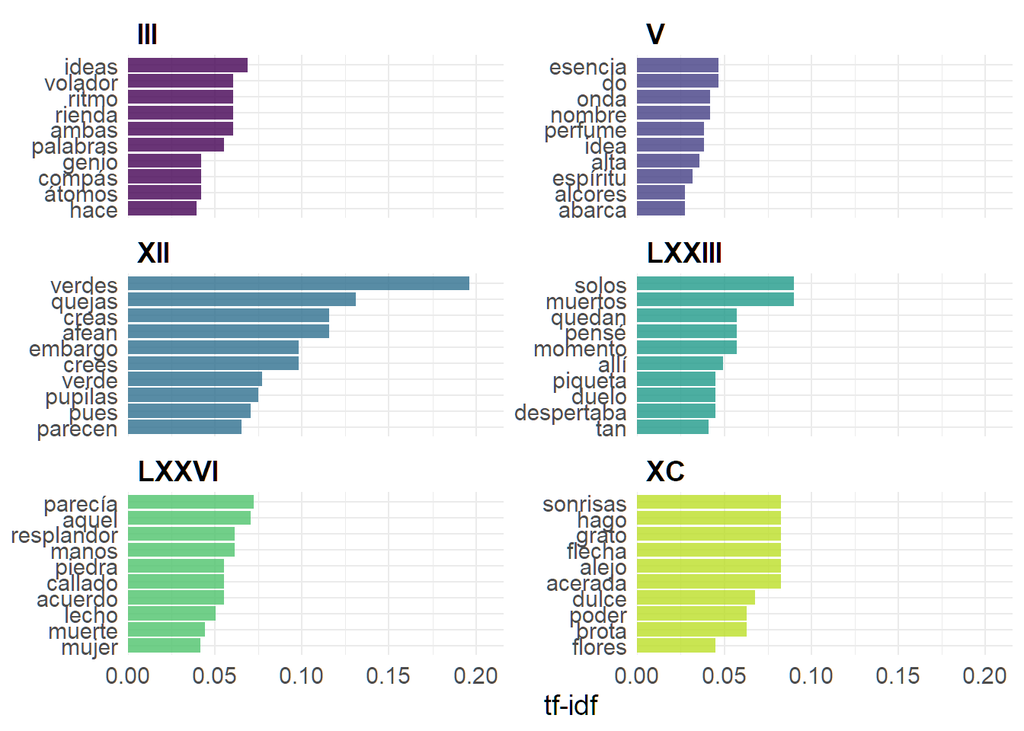

Figura 1: Las 10 palabras más distintivas en las 6 rimas más extensas

Es interesante observar la Figura 1: la tercera pone al genio (poeta) como único domador de la mezquina palabra, para domar las ideas (o ponerles riendas), para así, crear poesía. La quinta rima consiste en la esencia del poeta (Bécquer). Aquí se conciben palabras asociadas con esencia, como espíritu y perfume. Además, el autor usa la contracción “do” (donde), porque la esencia del poeta abarca lugares donde otras esencias no llegan.

Para llevar el análisis de palabras “un paso más allá”, podríamos estudiar el contexto de las palabras y su asociación con sentimientos, utilizando un léxico en español. En este ejercicio no realizaremos esto, pero sí mencionaremos [este léxico de sentimientos en 81 idiomas](https://www.kaggle.com/datasets/rtatman/sentiment-lexicons-for-81-languages) (también podemos utilizar el ampliamente divulgado [léxico NRC](http://saifmohammad.com/WebPages/NRC-Emotion-Lexicon.htm)).

Antes de continuar con el análisis, observemos que no realizamos una transformación de tokens, sea lematización o stemming; no es necesario hacer una búsqueda de faltas ortográficas, porque el texto es una obra revisada y publicada. En la sección siguiente, realizaremos una transformación para garantizar que la red de tokens evalúa de manera equivalente todas las formas verbales de una palabra.

### 5. Procesamiento de texto

Ambas stemming y lematización nos permiten reducir una palabra a su raíz. Stemming es un algoritmo rápido pero genera palabras ficticias, dificultando la interpretación de los resultados; lematización es un algoritmo lento, pero los resultados son fácilmente interpretables. Por las razones expuestas y debido a que el texto no es extenso, utilizaremos lematización, implementada en python en el paquete spacy, al que accedemos en R a través de la api del paquete `spacyr`.

Lo primero, es instalar `reticulate`, la interfaz que provee interoperabilidad entre R y python. [Este link](https://www.r-bloggers.com/2022/04/getting-started-with-python-using-r-and-reticulate/) provee una guía actualizada (2022) y sencilla de cómo instalar reticulate y el gestor de paquetes miniconda (es muy sencillo). Acto seguido, debemos instalar y configurar spacy mediante R:

```r
library(spacyr)
# Instalación de spacy en un entorno virtual de python (conda es el default)
# spacy_install()

# Descargar el modelo de lenguaje en español
# spacy_download_langmodel(model = 'es')

# Inicializar el modelo de lenguaje
spacy_initialize(model = 'es_core_news_sm')
```

Ya podemos lematizar nuestros tokens. Esta operación es lenta y produce múltiples warnings, asociados al uso del léxico en español. Afortunadamente, la función `spacy_parse()` es paralelizable y funciona bien con el paquete `doParallel` de R. Aún así, no paralelizaremos en esta oportunidad.

```r
unigrams_lemas <-
  unigrams_clean|>
  mutate(lema = spacy_parse(unigram)$lemma)

suppressWarnings({

  bigrams_lemas <-
    bigrams_clean |>
    mutate(
      row = row_number(),
      lema = map(bigram, spacy_parse),
      token_id = map(lema, 'token_id'),
      token = map(lema, 'lemma')
    ) |>
    unnest(cols = c(token_id, token)) |>
    group_by(rima, row) |>
    summarise(bigram = paste(token, collapse = ' '),
              .groups = 'drop') |>
    select(-row)

})
```

### 6. Visualización de relaciones con redes de n-gramas

Una visualización común de todas las palabras simultáneamente es distribuyéndolas en un grafo, esto es, un arreglo de nodos conectados entre sí. El paquete `igraph` provee de funciones para manipular y analizar redes. Una manera de crear un grafo con datos *tidy* es con `graph_from_data_frame()`, que toma como argumento los enlaces de columnas para “from” y “a”, y atributos para los enlaces, en este caso, la frecuencia `n`.

```r
library(igraph)
bigram_graph <-
  bigrams_lemas |>
  separate(bigram, c('word1', 'word2'), sep = ' ', extra = 'drop') |>
  count(word1, word2, sort = TRUE) |>
  slice_max(n, n = 30) |>
  graph_from_data_frame()
```

Para graficar las relaciones, utilizaremos el paquete `ggraph`, que convierte un objeto igraph en un ggraph, un software de visualización en el estilo de ggplot2.

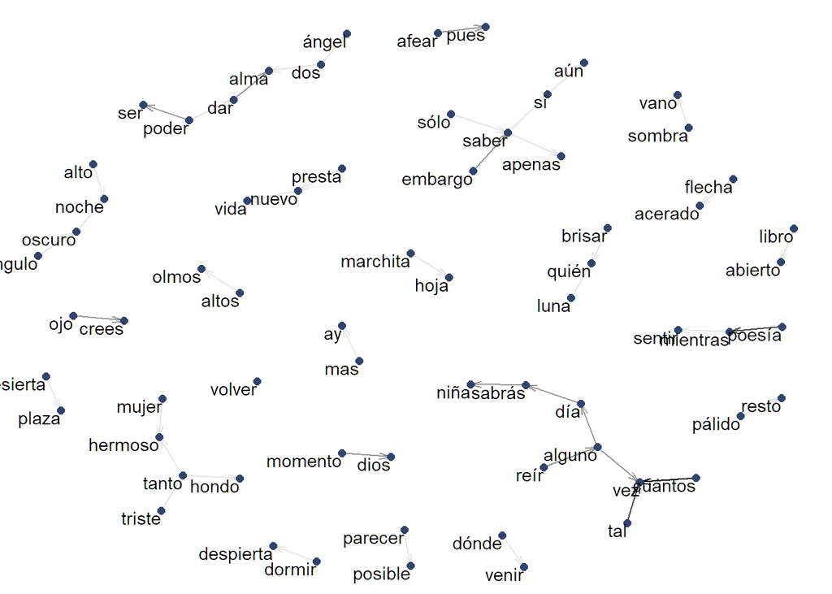

Figura 2: Diagrama de redes de palabras en la obra de Bécquer. La transparencia de los enlaces está dada por la frecuencia de la relación entre palabras

La Figura 2 ilustra las relaciones por frecuencia de bigramas. Este diagrama tiene una interpretación sencilla: es una sucesión de palabras. Este tipo de red también puede ser interpretada como una cadena de Markov, por ejemplo, la probabilidad de ocurrencia de la palabra (estado) “noche”, solamente depende de la(s) palabra(s) anterior(es), en este caso, la palabra “alto”.

Un tipo de red distinta es posible empleando estadísticos de correlación entre los unigramas, agrupándolos por rimas. Para ello, utilizaremos el paquete `widyr`, porque automatiza el conteo y el cálculo de correlación pareado.

```r
library(widyr)

unigram_pairs <- unigrams_lemas |>
  count(rima, lema) |>
  pairwise_count(lema, rima, sort = TRUE)
```

Noten que ahora podemos buscar los pares de palabras más comunes que incluyan la palabra “idea”.

```r
unigram_pairs |>
  filter(item1 == 'idea') |>
  slice_head(n = 6)
```

Tabla 3: Palabras que más frecuentemente acompañan a “idea”

| item1 | item2 | n |
| --- | --- | --- |
| idea | luz | 5 |
| idea | alma | 4 |
| idea | cielo | 4 |
| idea | nota | 3 |
| idea | mundo | 3 |
| idea | espíritu | 3 |

El coeficiente de correlación que usaremos será el [coeficiente de phi](https://en.wikipedia.org/wiki/Phi_coefficient), que es una medida común para correlación binaria. El foco del coeficiente de phi es cuán más probable es que dos palabras ocurran juntas, o que ninguna lo haga, comparado con que una ocurra sin la otra.

> El coeficiente de phi es equivalente a la correlación de Pearson, aplicada a datos binarios.

```r
unigram_cors <-
  unigrams_lemas |>
  group_by(lema) |>
  filter(n() > 15) |>
  pairwise_cor(lema, rima, sort = TRUE)
```

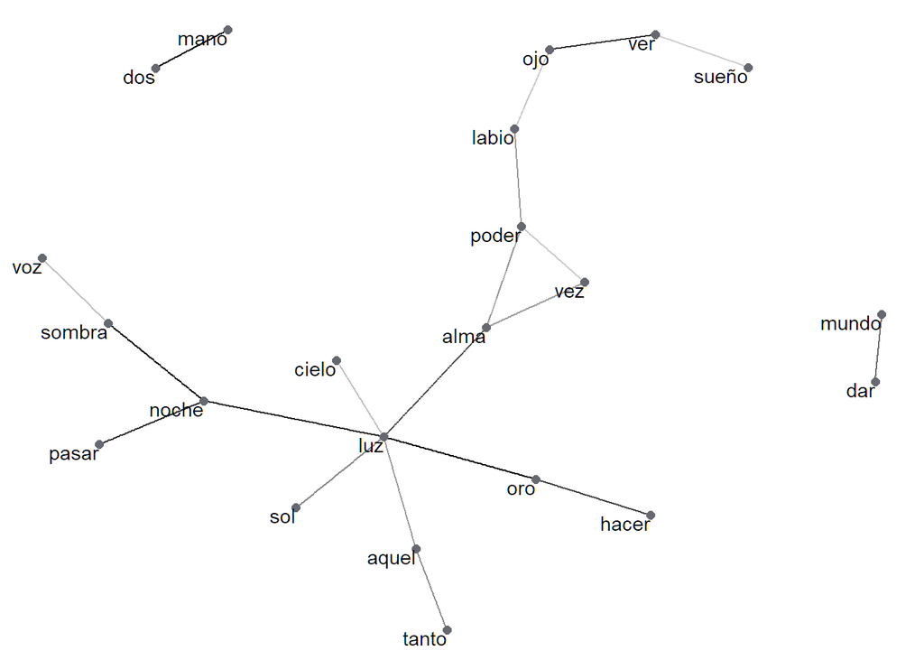

Figura 3: Diagrama de redes de palabras en la obra de Bécquer. La transparencia de los enlaces está dada por el índice de phi entre palabras de una misma rima